# Machine Learning Lab 2

**0. Import the data and declare your package dependencies.**

```python
import numpy as np
import pandas as pd
import plotnine as p9
```

```python
myData = pd.read_csv('/Users/richardhuang/Desktop/GSB-S544/Machine_Learning/avocado-updated-2020.csv')
```

```python
myData
```

```
             date  average_price  ...  year             geography
0      2015-01-04           1.22  ...  2015                Albany
1      2015-01-04           1.79  ...  2015                Albany
2      2015-01-04           1.00  ...  2015               Atlanta
3      2015-01-04           1.76  ...  2015               Atlanta
4      2015-01-04           1.08  ...  2015  Baltimore/Washington
...           ...            ...  ...   ...                   ...
33040  2020-11-29           1.47  ...  2020            Total U.S.
33041  2020-11-29           0.91  ...  2020                  West
33042  2020-11-29           1.48  ...  2020                  West
33043  2020-11-29           0.67  ...  2020   West Tex/New Mexico
33044  2020-11-29           1.35  ...  2020   West Tex/New Mexico

[33045 rows x 13 columns]
```

**1. Briefly describe the data set. What information does it contain?**

- `Date` - The date of the observation
- `AveragePrice` - the average price of a single avocado
- `type` - conventional or organic
- `year` - the year
- `Region` - the city or region of the observation
- `Total Volume` - Total number of avocados sold
- `4046` - Total number of avocados with PLU 4046 sold
- `4225` - Total number of avocados with PLU 4225 sold
- `4770` - Total number of avocados with PLU 4770 sold

It basically describes avocado’s prices and how they are sold. Besides the variables I listed above, it also has information regarding the bags that it is sold in.

**2. Clean the data in any way you see fit.**

```python
Major_geo = myData[myData['geography'].isin(['West', 'Midsouth', 'Northeast', 'South Central', 'Southeast', 'Plains'])]
Noncity = ['West', 'Midsouth', 'Northeast', 'South Central', 'Southeast', 'Plains','South Carolina','Total U.S.','West Tex/New Mexioco','Northern New England','California','Great Lakes']
Major_city=myData[~myData['geography'].isin(Noncity)]
```

```python
Major_city
```

```
             date  average_price  ...  year             geography
0      2015-01-04           1.22  ...  2015                Albany
1      2015-01-04           1.79  ...  2015                Albany
2      2015-01-04           1.00  ...  2015               Atlanta
3      2015-01-04           1.76  ...  2015               Atlanta
4      2015-01-04           1.08  ...  2015  Baltimore/Washington
...           ...            ...  ...   ...                   ...
33036  2020-11-29           1.46  ...  2020              Syracuse
33037  2020-11-29           0.65  ...  2020                 Tampa
33038  2020-11-29           0.95  ...  2020                 Tampa
33043  2020-11-29           0.67  ...  2020   West Tex/New Mexico
33044  2020-11-29           1.35  ...  2020   West Tex/New Mexico

[26313 rows x 13 columns]
```

```python
Major_geo
```

```
             date  average_price  ...  year      geography
50     2015-01-04           1.10  ...  2015       Midsouth
51     2015-01-04           1.56  ...  2015       Midsouth
58     2015-01-04           1.09  ...  2015      Northeast
59     2015-01-04           1.88  ...  2015      Northeast
70     2015-01-04           1.01  ...  2015         Plains
...           ...            ...  ...   ...            ...
33028  2020-11-29           1.21  ...  2020  South Central
33029  2020-11-29           0.70  ...  2020      Southeast
33030  2020-11-29           1.23  ...  2020      Southeast
33041  2020-11-29           0.91  ...  2020           West
33042  2020-11-29           1.48  ...  2020           West

[3672 rows x 13 columns]
```

**3. Which major geographical region sold the most total organic, small Hass avocados in 2017?**

```python
question_three = Major_geo[Major_geo["year"] == 2017]
question_three = question_three[question_three['type']=='organic']
sales_by_year = question_three.groupby('geography')['4046'].sum().reset_index()
sales_by_year
```

```
       geography        4046
0       Midsouth   186395.50
1      Northeast   925832.36
2         Plains   168583.40
3  South Central  1717104.19
4      Southeast   285124.34
5           West  1870206.29
```

West has the highest sales for **organic, small Hass avocados in 2017.**

**4. Split the `date` variable into month, day, and year variables. In which month is the highest average volume of avocado sales?**

```python
myData[['year', 'month', 'day']] = myData['date'].str.split('-', n=2, expand=True)


myData
```

```
             date  average_price  total_volume  ...             geography  month  day
0      2015-01-04           1.22      40873.28  ...                Albany     01   04
1      2015-01-04           1.79       1373.95  ...                Albany     01   04
2      2015-01-04           1.00     435021.49  ...               Atlanta     01   04
3      2015-01-04           1.76       3846.69  ...               Atlanta     01   04
4      2015-01-04           1.08     788025.06  ...  Baltimore/Washington     01   04
...           ...            ...           ...  ...                   ...    ...  ...
33040  2020-11-29           1.47    1583056.27  ...            Total U.S.     11   29
33041  2020-11-29           0.91    5811114.22  ...                  West     11   29
33042  2020-11-29           1.48     289961.27  ...                  West     11   29
33043  2020-11-29           0.67     822818.75  ...   West Tex/New Mexico     11   29
33044  2020-11-29           1.35      24106.58  ...   West Tex/New Mexico     11   29

[33045 rows x 15 columns]
```

```python
sales_by_month = myData.groupby('month')['total_volume'].mean().reset_index()
sorted_data =sales_by_month.sort_values(by='total_volume')
sorted_data
```

```
   month  total_volume
11    12  8.076695e+05
10    11  8.223470e+05
9     10  8.446863e+05
8     09  9.064773e+05
7     08  9.499249e+05
6     07  9.832681e+05
0     01  9.853122e+05
2     03  9.957150e+05
3     04  1.016582e+06
5     06  1.051247e+06
1     02  1.095374e+06
4     05  1.123632e+06
```

May has highest average.

**5. Which metro area geographical regions sold the most total avocados? Plot side-by-side box-plots of the total volume for only the five metro geographical regions with the highest averages for the `total_volume` variable.**

```python
Major_city
```

```
             date  average_price  ...  year             geography
0      2015-01-04           1.22  ...  2015                Albany
1      2015-01-04           1.79  ...  2015                Albany
2      2015-01-04           1.00  ...  2015               Atlanta
3      2015-01-04           1.76  ...  2015               Atlanta
4      2015-01-04           1.08  ...  2015  Baltimore/Washington
...           ...            ...  ...   ...                   ...
33036  2020-11-29           1.46  ...  2020              Syracuse
33037  2020-11-29           0.65  ...  2020                 Tampa
33038  2020-11-29           0.95  ...  2020                 Tampa
33043  2020-11-29           0.67  ...  2020   West Tex/New Mexico
33044  2020-11-29           1.35  ...  2020   West Tex/New Mexico

[26313 rows x 13 columns]
```

```python
sales_by_city = Major_city.groupby('geography')['total_volume'].sum().reset_index()
sorted_city =sales_by_city.sort_values(by='total_volume')
sorted_city
```

```
               geography  total_volume
40              Syracuse  2.412871e+07
3                  Boise  3.035955e+07
38               Spokane  3.078100e+07
0                 Albany  3.481634e+07
21            Louisville  3.489267e+07
29            Pittsburgh  4.109569e+07
5      Buffalo/Rochester  5.120092e+07
33               Roanoke  5.517729e+07
13          Grand Rapids  5.896980e+07
18          Jacksonville  6.220746e+07
39             St. Louis  6.316405e+07
9               Columbus  6.593675e+07
17          Indianapolis  6.640588e+07
23             Nashville  7.745375e+07
```

[output cut: 29 more lines]

Los Angeles sold the most avocados.

```python
top_five_city = myData[myData['geography'].isin(['Los Angeles', 'New York', 'Dallas/Ft. Worth', 'Houston', 'Phoenix/Tucson'])]

top_five_city
```

```
             date  average_price  total_volume  ...         geography  month  day
22     2015-01-04           0.74    1086363.97  ...  Dallas/Ft. Worth     01   04
23     2015-01-04           1.35       9895.96  ...  Dallas/Ft. Worth     01   04
36     2015-01-04           0.71    1062990.62  ...           Houston     01   04
37     2015-01-04           1.22       8938.32  ...           Houston     01   04
44     2015-01-04           0.85    2682159.95  ...       Los Angeles     01   04
...           ...            ...           ...  ...               ...    ...  ...
32982  2020-11-29           1.74     135939.83  ...       Los Angeles     11   29
32993  2020-11-29           1.07    1907738.81  ...          New York     11   29
32994  2020-11-29           1.73      69523.99  ...          New York     11   29
33003  2020-11-29           0.76     936684.60  ...    Phoenix/Tucson     11   29
33004  2020-11-29           1.30      24377.24  ...    Phoenix/Tucson     11   29

[3060 rows x 15 columns]
```

```python
import seaborn as sns
import matplotlib.pyplot as plt

plt.figure(figsize=(10, 50))
sns.boxplot(x="geography", y="total_volume", data=top_five_city)
plt.xlabel("Geography")
plt.ylabel("Total Volume")
plt.title("Box Plot of Total Volume by Geography")
plt.xticks(rotation=10)
```

```
([0, 1, 2, 3, 4], [Text(0, 0, 'Dallas/Ft. Worth'), Text(1, 0, 'Houston'), Text(2, 0, 'Los Angeles'), Text(3, 0, 'New York'), Text(4, 0, 'Phoenix/Tucson')])
```

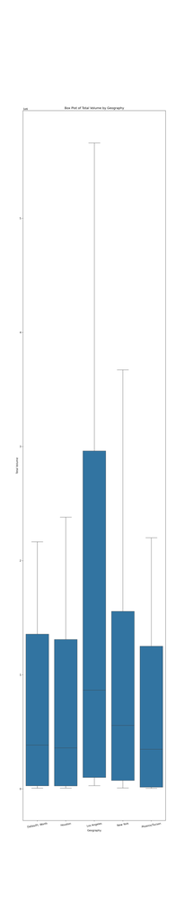

```python
plt.show()
```

The following four California geographical regions are in this data set: `"Los Angeles"`, `"San Diego"`, `"Sacramento"`, and `"San Francisco"`.

**6. From your cleaned data set, create a data set with only these California regions and answer the following questions about these California regions only.**

```python
California = myData[myData['geography'].isin(['Los Angeles', 'San Diego', 'Sacramento', 'San Francisco'])]
California
```

```
             date  average_price  total_volume  ...      geography  month  day
44     2015-01-04           0.85    2682159.95  ...    Los Angeles     01   04
45     2015-01-04           1.25      54495.54  ...    Los Angeles     01   04
80     2015-01-04           1.05     430138.88  ...     Sacramento     01   04
81     2015-01-04           1.33       9213.49  ...     Sacramento     01   04
82     2015-01-04           0.94     461607.33  ...      San Diego     01   04
...           ...            ...           ...  ...            ...    ...  ...
33018  2020-11-29           1.43      23531.38  ...     Sacramento     11   29
33019  2020-11-29           1.12     469356.72  ...      San Diego     11   29
33020  2020-11-29           1.95      25799.95  ...      San Diego     11   29
33021  2020-11-29           1.50     644141.37  ...  San Francisco     11   29
33022  2020-11-29           1.87      59527.02  ...  San Francisco     11   29

[2448 rows x 15 columns]
```

**7. In which California regions is the price of organic versus conventional avocados most different? Support your answer with a few summary statistics AND a visualization.**

**Tip**

You do not have to, but you may want to transform your data. Sketch out what you want the data set to look like before you begin to code! Come up with a game plan to answer this question.

```python
California.loc[:, 'average_price'] = California['average_price'].astype(int)
```

```python
import pandas as pd
grouped = California.groupby(['type', 'geography'])['average_price'].mean().reset_index()
pivot_table = grouped.pivot(index='geography', columns='type', values='average_price')
pivot_table['difference'] = pivot_table['organic'] - pivot_table['conventional']
pivot_table.reset_index(inplace=True)


pivot_table
```

```
type      geography  conventional   organic  difference
0       Los Angeles      0.571895  1.098039    0.526144
1        Sacramento      0.944444  1.303922    0.359477
2         San Diego      0.696078  1.251634    0.555556
3     San Francisco      0.937908  1.607843    0.669935
```

```python
grouped.describe()
```

```
       average_price
count       8.000000
mean        1.051471
std         0.337250
min         0.571895
25%         0.877451
50%         1.021242
75%         1.264706
max         1.607843
```

```python
from plotnine import ggplot, geom_point, aes, geom_boxplot, geom_bar
gg=(ggplot(pivot_table,
aes(
  x = "geography",
  y = "difference"
))
+ geom_bar(stat='identity')
)
```

San Francisco has the highest difference price of 0.67, while San Diego has the second most difference price of 0.56. On the other hand, Sacramento has the lowest difference between organic and conventional.

**8. The following plot shows, for all four California regions, the proportion of the average Hass avocado sales that are small, large, or extra large; conventional vs. organic. Recreate the plot; you do not have to replicate the exact finishing touches - e.g., color, theme - but your plot should resemble the content of this plot.**

```python
California
```

```
             date  average_price  total_volume  ...      geography  month  day
44     2015-01-04            0.0    2682159.95  ...    Los Angeles     01   04
45     2015-01-04            1.0      54495.54  ...    Los Angeles     01   04
80     2015-01-04            1.0     430138.88  ...     Sacramento     01   04
81     2015-01-04            1.0       9213.49  ...     Sacramento     01   04
82     2015-01-04            0.0     461607.33  ...      San Diego     01   04
...           ...            ...           ...  ...            ...    ...  ...
33018  2020-11-29            1.0      23531.38  ...     Sacramento     11   29
33019  2020-11-29            1.0     469356.72  ...      San Diego     11   29
33020  2020-11-29            1.0      25799.95  ...      San Diego     11   29
33021  2020-11-29            1.0     644141.37  ...  San Francisco     11   29
33022  2020-11-29            1.0      59527.02  ...  San Francisco     11   29

[2448 rows x 15 columns]
```

```python
Cali = California.groupby(['type', 'geography','4770','4225','4046'])['average_price'].sum().reset_index()
Cali
```

```
              type      geography  ...        4046  average_price
0     conventional    Los Angeles  ...  1409249.49            0.0
1     conventional    Los Angeles  ...   768315.72            1.0
2     conventional    Los Angeles  ...   847807.44            1.0
3     conventional    Los Angeles  ...  1217417.81            0.0
4     conventional    Los Angeles  ...   865743.41            1.0
...            ...            ...  ...         ...            ...
2435       organic  San Francisco  ...    15960.40            2.0
2436       organic  San Francisco  ...    15236.95            2.0
2437       organic  San Francisco  ...     4029.00            1.0
2438       organic  San Francisco  ...    13329.09            2.0
2439       organic  San Francisco  ...    10931.42            1.0

[2440 rows x 6 columns]
```

```python
long_Cali = Cali.melt(id_vars=["geography", "type"], value_vars= ['4770','4225','4046'],var_name="size", value_name="count")
```

```
<Figure Size: (1280 x 960)>
```

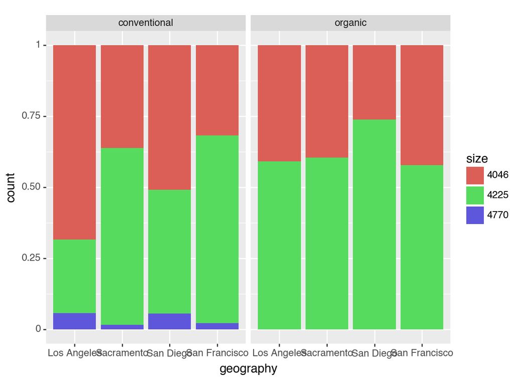

```python
import pandas as pd
import matplotlib.pyplot as plt

from plotnine import facet_wrap, geom_col
(ggplot(long_Cali,
aes(
x = "geography", y ='count',
  fill = 'size'
))
+ geom_col(position = "fill")
+ facet_wrap("type")
)
```

#My size is upside down.

# **Using Outside Data**

A joke in the media is that Millennials can't afford houses, because they spend all their money buying avocado toast. Let's use this data set to address that claim.

#Randomly generating a house_price data frame based on different cities:

```python
import pandas as pd
import random


cities = ['Los Angeles', 'San Diego', 'Sacramento', 'San Francisco']

data = []

for _ in range(100):

    city = random.choice(cities)  # Randomly select a city from the list

    house_price = random.randint(300000, 1000000)
    data.append({'geography': city, 'house_price': house_price})

house_prices_df = pd.DataFrame(data)

print(house_prices_df)
```

```
        geography  house_price
0   San Francisco       747284
1     Los Angeles       819750
2      Sacramento       735106
3       San Diego       933405
4      Sacramento       995093
..            ...          ...
95     Sacramento       764687
96     Sacramento       943286
97  San Francisco       309300
98    Los Angeles       734375
99    Los Angeles       328453

[100 rows x 2 columns]
```

```python
House = house_prices_df.groupby(['geography'])['house_price'].mean().reset_index()
House
```

```
       geography    house_price
0    Los Angeles  684558.607143
1     Sacramento  667596.740741
2      San Diego  667545.000000
3  San Francisco  640068.100000
```

```python
avo = Cali.groupby(['geography'])['average_price'].mean().reset_index()
avo
```

```
       geography  average_price
0    Los Angeles       0.837705
1     Sacramento       1.127869
2      San Diego       0.977049
3  San Francisco       1.277049
```

```python
final = avo.merge(House, on=["geography"])
final
```

```
       geography  average_price    house_price
0    Los Angeles       0.837705  684558.607143
1     Sacramento       1.127869  667596.740741
2      San Diego       0.977049  667545.000000
3  San Francisco       1.277049  640068.100000
```

```
<Figure Size: (1280 x 960)>
```

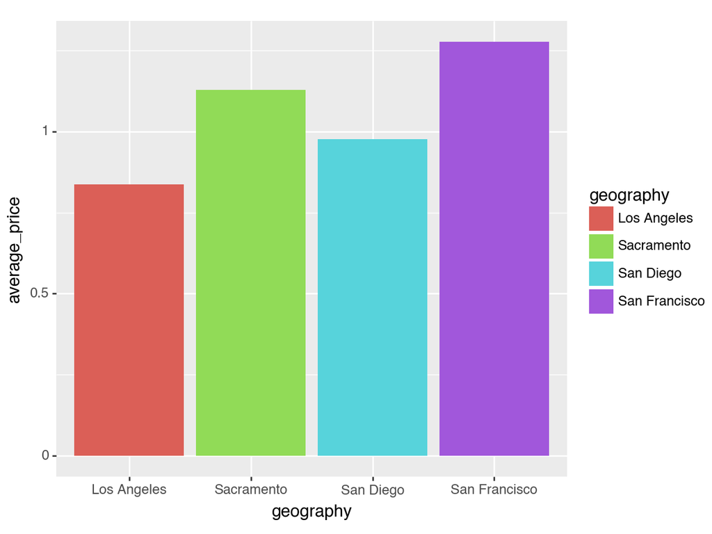

```python
from plotnine import facet_wrap, geom_col, ggplot,aes,geom_bar
(ggplot(final, aes(x = "geography", y = "average_price", fill = "geography"))
+ geom_bar(stat='identity')
)
```

```
<Figure Size: (1280 x 960)>
```

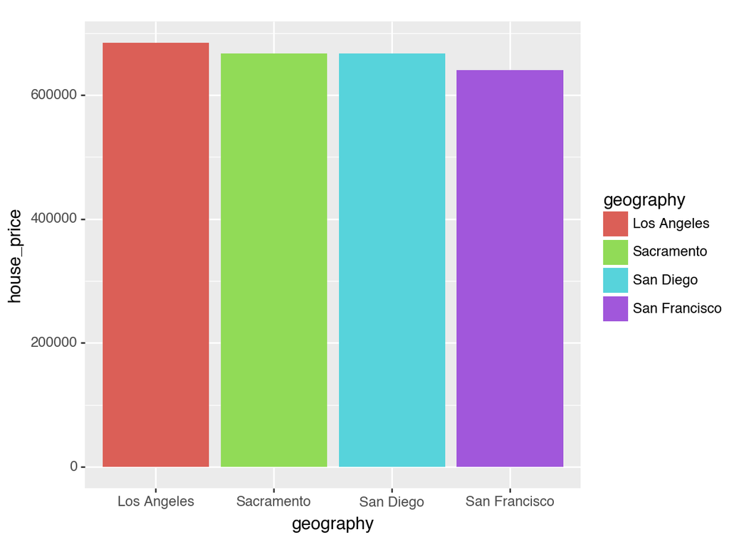

```python
from plotnine import facet_wrap, geom_col, ggplot,aes,geom_bar
(ggplot(final, aes(x = "geography", y = "house_price", fill = "geography"))
+ geom_bar(stat='identity')
)
```

To argue about “Millennials can't afford houses, because they spend all their money buying avocado toast”, I made two graphs: one desribes the average price of avocado based on the four different cities, the other one describes the average house price based on the four different cities.

If it’s true that Millennials spend all their money buying avocado toast, we can interprete that the average prices of avocado in a city is too high. Meanwhile, the average prices of house in a city is relatively low. (Since people can’t afford it, real estate will set it to a lower price. If people can afford it and they have been buying it, the prices of house should be high. Supply/Demand relationship).

Relatively speaking, SF has the highest avocado price, and it also happens to have the lowest house price, which fits my interpretation in the previous paragraph. Therefore, it is true for Millennials in SF that they can't afford houses, because they spend all their money buying avocado toast.

On the other hand, LA is in the opposite position. They have the lowest avocado prices but a relatively high house price, indicating that when avocado are cheap, people are buying more houses.